# Bayesian workshop - 6 November 2020

## Recap

Last time I introduced basic ideas of Bayesian inference. We finished with a relatively simple model estimating species- and site-specific means of LMA from data that was part of Kristen’s dissertation. Someone asked about ANOVA-like comparisons of means among the species. Let’s work through that before moving on to linear regression and selection of covariates.

[output not shown]

## Posterior comparisons

First, we need to rerun the model from last time. I tend to store the results in an object I call `fit`, but you can give it any name that you find convenient.

```r
dat <- read.csv("Protea_traits_dataset_for_workshop.csv",
                header = TRUE,
                na.strings = ".")

fit <- stan_glmer(LMA_g.cm2 ~ (1|Species/Site),
                  data = dat,
                  family = gaussian(),
                  refresh = 0)
summary(fit, digits = 3, probs = c(0.025, 0.1, 0.5, 0.9, 0.975))
```

```
Model Info:
 function:     stan_glmer
 family:       gaussian [identity]
 formula:      LMA_g.cm2 ~ (1 | Species/Site)
 algorithm:    sampling
 sample:       4000 (posterior sample size)
 priors:       see help('prior_summary')
 observations: 151
 groups:       Site:Species (9), Species (5)

Estimates:
                                              mean   sd     2.5%   10%    50%    90%    97.5%
(Intercept)                                  0.030  0.003  0.024  0.027  0.030  0.034  0.036
b[(Intercept) Site:Species:Cederberg:PRLA]   0.001  0.001 -0.001  0.000  0.000  0.002  0.004
b[(Intercept) Site:Species:Cederberg:PRNI]   0.000  0.001 -0.002 -0.001  0.000  0.001  0.003
b[(Intercept) Site:Species:Cederberg:PRRE]   0.001  0.001 -0.001  0.000  0.000  0.002  0.002
b[(Intercept) Site:Species:Jonaskop:PRLA]    0.000  0.001 -0.002 -0.001  0.000  0.001  0.003
b[(Intercept) Site:Species:Jonaskop:PRPU]   -0.001  0.001 -0.003 -0.002  0.000  0.000  0.001
b[(Intercept) Site:Species:Jonaskop:PRRE]    0.000  0.001 -0.001 -0.001  0.000  0.001  0.002
b[(Intercept) Site:Species:Swartberg:PREX]   0.000  0.002 -0.005 -0.002  0.000  0.001  0.002
b[(Intercept) Site:Species:Swartberg:PRPU]   0.000  0.001 -0.002 -0.001  0.000  0.001  0.002
b[(Intercept) Site:Species:Swartberg:PRRE]  -0.001  0.001 -0.003 -0.002 -0.001  0.000  0.001
b[(Intercept) Species:PREX]                 -0.009  0.003 -0.015 -0.013 -0.009 -0.005 -0.002
b[(Intercept) Species:PRLA]                  0.009  0.003  0.003  0.005  0.009  0.013  0.015
b[(Intercept) Species:PRNI]                  0.002  0.003 -0.004 -0.002  0.002  0.006  0.009
b[(Intercept) Species:PRPU]                 -0.003  0.003 -0.009 -0.006 -0.003  0.001  0.003
b[(Intercept) Species:PRRE]                  0.000  0.003 -0.006 -0.004  0.000  0.004  0.006
sigma                                        0.002  0.000  0.002  0.002  0.002  0.003  0.003
Sigma[Site:Species:(Intercept),(Intercept)]  0.000  0.000  0.000  0.000  0.000  0.000  0.000
Sigma[Species:(Intercept),(Intercept)]       0.000  0.000  0.000  0.000  0.000  0.000  0.000

Fit Diagnostics:
           mean   sd    2.5%   10%   50%   90%   97.5%
mean_PPD 0.031  0.000 0.030  0.031 0.031 0.031 0.031

The mean_ppd is the sample average posterior predictive distribution of the outcome variable (for details see help('summary.stanreg')).

MCMC diagnostics
                                            mcse  Rhat  n_eff
(Intercept)                                 0.000 1.000 1520
b[(Intercept) Site:Species:Cederberg:PRLA]  0.000 1.005  821
b[(Intercept) Site:Species:Cederberg:PRNI]  0.000 0.999 3493
b[(Intercept) Site:Species:Cederberg:PRRE]  0.000 1.000 2952
b[(Intercept) Site:Species:Jonaskop:PRLA]   0.000 1.004  866
b[(Intercept) Site:Species:Jonaskop:PRPU]   0.000 1.002 1732
b[(Intercept) Site:Species:Jonaskop:PRRE]   0.000 1.000 3049
b[(Intercept) Site:Species:Swartberg:PREX]  0.000 1.007  713
b[(Intercept) Site:Species:Swartberg:PRPU]  0.000 1.001 2104
b[(Intercept) Site:Species:Swartberg:PRRE]  0.000 1.000 2651
b[(Intercept) Species:PREX]                 0.000 1.003 1322
b[(Intercept) Species:PRLA]                 0.000 1.000 1211
b[(Intercept) Species:PRNI]                 0.000 1.000 1673
b[(Intercept) Species:PRPU]                 0.000 1.001 1548
b[(Intercept) Species:PRRE]                 0.000 1.000 1556
sigma                                       0.000 1.000 4716
Sigma[Site:Species:(Intercept),(Intercept)] 0.000 1.007  479
Sigma[Species:(Intercept),(Intercept)]      0.000 1.001 2320
mean_PPD                                    0.000 1.000 3674
log-posterior                               0.126 1.003  960

For each parameter, mcse is Monte Carlo standard error, n_eff is a crude measure of effective sample size, and Rhat is the potential scale reduction factor on split chains (at convergence Rhat=1).
```

We can now extract the posterior distribution. There are several ways to do it, but I find that the easiest is often to convert the output to a data frame.

```r
fit_df <- as.data.frame(fit)
colnames(fit_df)
```

```
 [1] "(Intercept)"                                 "b[(Intercept) Site:Species:Cederberg:PRLA]"
 [3] "b[(Intercept) Site:Species:Cederberg:PRNI]"  "b[(Intercept) Site:Species:Cederberg:PRRE]"
 [5] "b[(Intercept) Site:Species:Jonaskop:PRLA]"   "b[(Intercept) Site:Species:Jonaskop:PRPU]"
 [7] "b[(Intercept) Site:Species:Jonaskop:PRRE]"   "b[(Intercept) Site:Species:Swartberg:PREX]"
 [9] "b[(Intercept) Site:Species:Swartberg:PRPU]"  "b[(Intercept) Site:Species:Swartberg:PRRE]"
[11] "b[(Intercept) Species:PREX]"                 "b[(Intercept) Species:PRLA]"
[13] "b[(Intercept) Species:PRNI]"                 "b[(Intercept) Species:PRPU]"
[15] "b[(Intercept) Species:PRRE]"                 "sigma"
[17] "Sigma[Site:Species:(Intercept),(Intercept)]" "Sigma[Species:(Intercept),(Intercept)]"
```

As you can see, the column names in this data frame match those used in reporting the results. We can verify that they mean the same thing by looking at the mean and 95% credible intervals.

```r
coefficient <- colnames(fit_df)
mean <- numeric(0)
lo <- numeric(0)
hi <- numeric(0)
for (i in 1:length(coefficient)) {
  mean[i] <- mean(fit_df[, i])
  lo[i] <- quantile(fit_df[, i], 0.025)
  hi[i] <- quantile(fit_df[, i], 0.975)
}
results <- data.frame(coefficient = coefficient,
                      mean = mean,
                      lo = lo,
                      hi = hi)
knitr::kable(results, col.names = c("Coefficient", "Mean", "2.5%", "97.5%"), digits = 3)
```

| Coefficient | Mean | 2.5% | 97.5% |
| --- | --- | --- | --- |
| (Intercept) | 0.030 | 0.024 | 0.036 |
| b[(Intercept) Site:Species:Cederberg:PRLA] | 0.001 | -0.001 | 0.004 |
| b[(Intercept) Site:Species:Cederberg:PRNI] | 0.000 | -0.002 | 0.003 |
| b[(Intercept) Site:Species:Cederberg:PRRE] | 0.001 | -0.001 | 0.002 |
| b[(Intercept) Site:Species:Jonaskop:PRLA] | 0.000 | -0.002 | 0.003 |
| b[(Intercept) Site:Species:Jonaskop:PRPU] | -0.001 | -0.003 | 0.001 |
| b[(Intercept) Site:Species:Jonaskop:PRRE] | 0.000 | -0.001 | 0.002 |
| b[(Intercept) Site:Species:Swartberg:PREX] | 0.000 | -0.005 | 0.002 |
| b[(Intercept) Site:Species:Swartberg:PRPU] | 0.000 | -0.002 | 0.002 |
| b[(Intercept) Site:Species:Swartberg:PRRE] | -0.001 | -0.003 | 0.001 |
| b[(Intercept) Species:PREX] | -0.009 | -0.015 | -0.002 |
| b[(Intercept) Species:PRLA] | 0.009 | 0.003 | 0.015 |
| b[(Intercept) Species:PRNI] | 0.002 | -0.004 | 0.009 |
| b[(Intercept) Species:PRPU] | -0.003 | -0.009 | 0.003 |
| b[(Intercept) Species:PRRE] | 0.000 | -0.006 | 0.006 |
| sigma | 0.002 | 0.002 | 0.003 |
| Sigma[Site:Species:(Intercept),(Intercept)] | 0.000 | 0.000 | 0.000 |
| Sigma[Species:(Intercept),(Intercept)] | 0.000 | 0.000 | 0.000 |

Before we go any further, let me illustrate what I mean when I say that we have the full posterior distribution for these parameters. We’ll start by comparing the species effect for *Protea eximia* (PREX), *Protea laurifolia* (PRLA), and (my personal favorite) *Protea punctata* (PRPU).

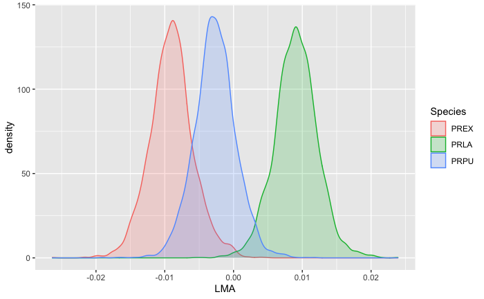

```r
n_samples <- nsamples(fit)
for_plot <- data.frame(Species = c(rep("PREX", n_samples), rep("PRLA", n_samples),
                                   rep("PRPU", n_samples)),
                       LMA = c(fit_df$`b[(Intercept) Species:PREX]`,
                               fit_df$`b[(Intercept) Species:PRLA]`,
                               fit_df$`b[(Intercept) Species:PRPU]`))
p <- ggplot(for_plot, aes(x = LMA, color = Species, fill = Species)) + geom_density(alpha = 0.2)
print(p)
```

The posterior distributions for *Protea eximia* and *Protea laurifolia* overlap a tiny bit. If you look back, you’ll see that the 95% credible intervals don’t overlap, so we’re confident that *Protea laurifolia* has denser leaves than *Protea eximia*. But what about *Protea punctata*? That’s where posterior comparisons come in.[^1]

```r
diff_pu_ex <- fit_df$`b[(Intercept) Species:PRPU]` - fit_df$`b[(Intercept) Species:PREX]`
diff_pu_la <- fit_df$`b[(Intercept) Species:PRPU]` - fit_df$`b[(Intercept) Species:PRLA]`

results <- data.frame(comp = c("PRPU vs. PREX", "PRPU vx. PRLA"),
                      mean = c(mean(diff_pu_ex), mean(diff_pu_la)),
                      lo = c(quantile(diff_pu_ex, 0.025),
                             quantile(diff_pu_la, 0.025)),
                      hi = c(quantile(diff_pu_ex, 0.975),
                             quantile(diff_pu_la, 0.975)))
knitr::kable(results, col.names = c("Comparison", "Mean", "2.5%", "97.5%"), digits = 3)
```

| Comparison | Mean | 2.5% | 97.5% |
| --- | --- | --- | --- |
| PRPU vs. PREX | 0.006 | 0.002 | 0.009 |
| PRPU vx. PRLA | -0.012 | -0.014 | -0.008 |

So in both cases the posterior distribution of the difference does not overlap 0 meaning that we have reasonably strong evidence that *Protea punctata* leaves are denser than those of *Protea eximia* and less dense than those of *Protea laurifolia*.

## Examining associations among traits

Kristen’s data includes measurements of photosynthetic rate, specifically the light-saturated rate of photosynthesis per unit area. How is the rate of photoynthesis related to wood density, stem conductance (Ks and KL), bark width, leaf thickness, leaf area, LMA, leaf length-width ratio, leaf density, stomatal length, stomatal density, and stomatal pore index.[^2]

```r
fit <- stan_glm(Photo ~ WD + Ks + KL_Units + BW_dry_avg + Thick_cm + Area_cm2 + LMA_g.cm2 +
                  LWR + LD_g.cm3 +
                  Length_mm_Top + Density_mm2_Top + SPI_Top,
                data = dat,
                family = gaussian(),
                refresh = 0)
fit_df <- as.data.frame(fit)
summary(fit, digits = 3, probs = c(0.025, 0.1, 0.5, 0.9, 0.975))
```

```
Model Info:
 function:     stan_glm
 family:       gaussian [identity]
 formula:      Photo ~ WD + Ks + KL_Units + BW_dry_avg + Thick_cm + Area_cm2 +
       LMA_g.cm2 + LWR + LD_g.cm3 + Length_mm_Top + Density_mm2_Top +
       SPI_Top
 algorithm:    sampling
 sample:       4000 (posterior sample size)
 priors:       see help('prior_summary')
 observations: 151
 predictors:   13

Estimates:
                  mean       sd         2.5%       10%        50%        90%        97.5%
(Intercept)         31.157      8.922     13.174     19.957     31.079     42.284     48.681
WD                   2.683      4.736     -6.322     -3.408      2.681      8.841     11.928
Ks                   0.820      0.861     -0.897     -0.313      0.822      1.925      2.495
KL_Units         -2215.603   5307.901 -12663.283  -9106.785  -2107.341   4705.952   7817.308
BW_dry_avg          -0.424      0.969     -2.288     -1.662     -0.411      0.808      1.472
Thick_cm           -86.778    131.012   -344.649   -252.864    -87.303     75.661    174.028
Area_cm2             0.005      0.036     -0.066     -0.041      0.005      0.049      0.074
LMA_g.cm2           65.350    238.396   -410.438   -230.441     67.568    361.473    531.790
LWR                 -0.167      0.086     -0.336     -0.279     -0.166     -0.061     -0.001
LD_g.cm3             3.900     12.382    -20.396    -11.428      3.940     19.205     27.916
Length_mm_Top     -393.520    130.090   -645.451   -556.811   -395.605   -224.407   -135.673
Density_mm2_Top     -0.153      0.055     -0.259     -0.224     -0.152     -0.082     -0.042
SPI_Top             82.280     30.837     20.536     41.687     82.784    121.418    141.608
sigma                2.347      0.141      2.094      2.172      2.340      2.530      2.647

Fit Diagnostics:
           mean   sd     2.5%   10%    50%    90%    97.5%
mean_PPD 12.919  0.269 12.388 12.567 12.926 13.264 13.435

The mean_ppd is the sample average posterior predictive distribution of the outcome variable (for details see help('summary.stanreg')).

MCMC diagnostics
                mcse   Rhat   n_eff
(Intercept)      0.189  1.000 2239
WD               0.072  1.001 4375
Ks               0.014  1.000 3596
KL_Units        88.800  1.001 3573
BW_dry_avg       0.016  0.999 3720
Thick_cm         2.950  1.000 1972
Area_cm2         0.001  1.000 3511
LMA_g.cm2        5.312  1.000 2014
LWR              0.001  1.000 3638
LD_g.cm3         0.278  1.000 1981
Length_mm_Top    2.852  1.001 2080
Density_mm2_Top  0.001  1.001 2145
SPI_Top          0.674  1.001 2091
sigma            0.002  1.000 4093
mean_PPD         0.004  1.000 4856
log-posterior    0.074  1.000 1433

For each parameter, mcse is Monte Carlo standard error, n_eff is a crude measure of effective sample size, and Rhat is the potential scale reduction factor on split chains (at convergence Rhat=1).
```

I find it much easier to interpret the coefficients if we put them all on the same scale. Since they’re all continuous, it’s convenient to use `scale()` to do this for us.

```r
## drop the first column because it's the intercept and the last because it's sigma
##
for (trait in colnames(fit_df)[-c(1, ncol(fit_df))]) {
  dat[[trait]] <- as.numeric(scale(dat[[trait]]))
}
## use scale to center and standardize the response, too
##
dat$Photo <- as.numeric(scale(dat$Photo))

fit <- stan_glm(Photo ~ WD + Ks + KL_Units + BW_dry_avg + Thick_cm + Area_cm2 + LMA_g.cm2 + LWR + LD_g.cm3 +
                  Length_mm_Top + Density_mm2_Top + SPI_Top,
                data = dat,
                family = gaussian(),
                refresh = 0)
fit_df <- as.data.frame(fit)
summary(fit, digits = 3, probs = c(0.025, 0.1, 0.5, 0.9, 0.975))
```

```
Model Info:
 function:     stan_glm
 family:       gaussian [identity]
 formula:      Photo ~ WD + Ks + KL_Units + BW_dry_avg + Thick_cm + Area_cm2 +
       LMA_g.cm2 + LWR + LD_g.cm3 + Length_mm_Top + Density_mm2_Top +
       SPI_Top
 algorithm:    sampling
 sample:       4000 (posterior sample size)
 priors:       see help('prior_summary')
 observations: 151
 predictors:   13

Estimates:
                  mean   sd     2.5%   10%    50%    90%    97.5%
(Intercept)      0.000  0.074 -0.151 -0.093  0.001  0.095  0.139
WD               0.061  0.108 -0.154 -0.078  0.062  0.199  0.272
Ks               0.105  0.115 -0.119 -0.043  0.106  0.248  0.332
KL_Units        -0.044  0.112 -0.268 -0.187 -0.044  0.099  0.170
BW_dry_avg      -0.086  0.172 -0.418 -0.306 -0.087  0.132  0.257
Thick_cm        -0.414  0.647 -1.664 -1.238 -0.409  0.418  0.856
Area_cm2         0.031  0.171 -0.295 -0.188  0.032  0.250  0.364
LMA_g.cm2        0.153  0.578 -0.986 -0.589  0.150  0.895  1.295
LWR             -0.339  0.173 -0.676 -0.562 -0.340 -0.119  0.002
LD_g.cm3         0.139  0.441 -0.722 -0.424  0.145  0.712  0.982
Length_mm_Top   -1.796  0.573 -2.896 -2.521 -1.784 -1.068 -0.671
Density_mm2_Top -1.006  0.350 -1.689 -1.447 -0.997 -0.562 -0.323
SPI_Top          0.921  0.333  0.255  0.501  0.923  1.336  1.563
sigma            0.930  0.057  0.830  0.860  0.927  1.003  1.049

Fit Diagnostics:
           mean   sd     2.5%   10%    50%    90%    97.5%
mean_PPD  0.001  0.108 -0.208 -0.134  0.001  0.141  0.212

The mean_ppd is the sample average posterior predictive distribution of the outcome variable (for details see help('summary.stanreg')).

MCMC diagnostics
                mcse  Rhat  n_eff
(Intercept)     0.001 1.001 5391
WD              0.002 1.000 3615
Ks              0.002 1.000 3324
KL_Units        0.002 0.999 3539
BW_dry_avg      0.003 1.000 3092
Thick_cm        0.015 1.003 1769
Area_cm2        0.003 1.000 3138
LMA_g.cm2       0.014 1.003 1812
LWR             0.003 1.000 3334
LD_g.cm3        0.010 1.003 1796
Length_mm_Top   0.014 1.000 1786
Density_mm2_Top 0.008 1.000 1961
SPI_Top         0.008 1.000 1828
sigma           0.001 1.000 4231
mean_PPD        0.002 1.001 4850
log-posterior   0.069 1.001 1552

For each parameter, mcse is Monte Carlo standard error, n_eff is a crude measure of effective sample size, and Rhat is the potential scale reduction factor on split chains (at convergence Rhat=1).
```

Now we can see that the stomatal traits have strong associations with photosynthesis. Other associations we’re less sure of. How well does the model work? The easiest way is to use posterior predictive checking in `shinystan`.

When the number of coefficients estimated isn’t too large, it’s helpful to visualize the posterior distributions.

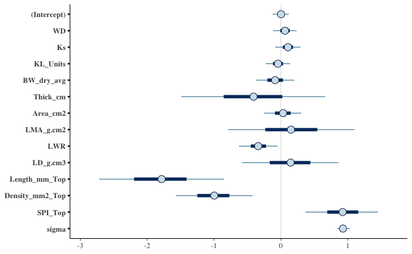

```r
plot(fit)
```

The light blue circle is the posterior median, the dark blue bar is the central 50% credible interval, and the light blue bar is the central 90% credible interval. If you’d rather see the posterior mean and the central 80% and 95% intervals, this is all you have to do.

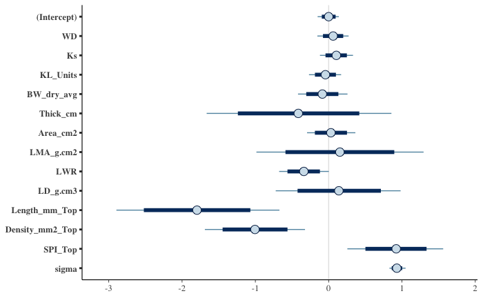

```r
plot(fit, point_est = "mean", prob = 0.8, prob_outer = 0.95)
```

## Where do priors come from?

`rstanarm` allows you to specify prior distributions for the parameters, but most of the time I use the defaults in `stan_glm()` and the other regression functions. There are a couple of ways you can examine them if you’re interested.

```r
prior_summary(fit)
```

```
Priors for model 'fit'
------
Intercept (after predictors centered)
  Specified prior:
    ~ normal(location = -2.5e-16, scale = 2.5)
  Adjusted prior:
    ~ normal(location = -2.5e-16, scale = 2.5)

Coefficients
  Specified prior:
    ~ normal(location = [0,0,0,...], scale = [2.5,2.5,2.5,...])
  Adjusted prior:
    ~ normal(location = [0,0,0,...], scale = [2.50,2.50,2.50,...])

Auxiliary (sigma)
  Specified prior:
    ~ exponential(rate = 1)
  Adjusted prior:
    ~ exponential(rate = 1)
------
See help('prior_summary.stanreg') for more details
```

```
Drawing from prior...
```

```
starting worker pid=23953 on localhost:11797 at 15:47:36.532
starting worker pid=23967 on localhost:11797 at 15:47:36.780
```

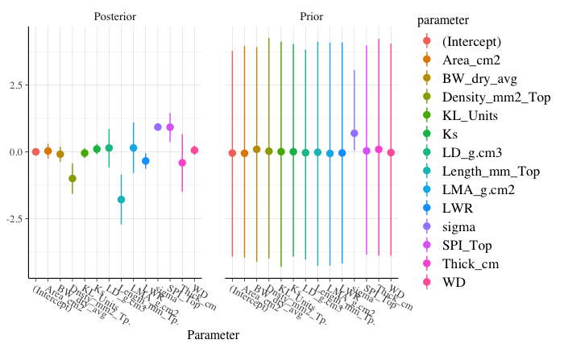

```r
posterior_vs_prior(fit)
```

## Selecting variables

You’ve probably heard of forward selection and backward selection as strategies for identifying which covariates are “worth” keeping in a multiple regression. You may also have heard of multiple subsets regression, in which all possible subsets of covariates are used and the “best” subset is chosen. Pironen and Vehtari colleagues introduced an approach that I like a lot better, the use of what are known as “regularized horseshoe priors.”[^3] Using them is very easy with `rstanarm`.[^4] Before we run the model with horseshoe priors on Kristen’s data, I’m going to create a really simple dummy data set and run two regression analyses, one with the default priors and one with the regularized horseshoe priors so that I can illustrate the difference between the two sets of priors.

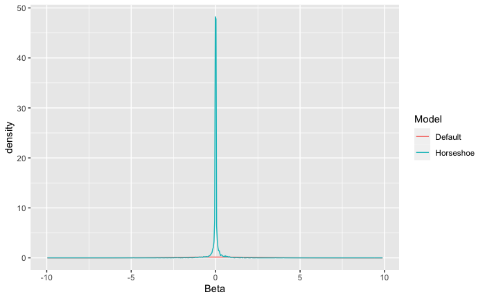

```r
## -2 because the estimates include the intercept and sigma
##
n_traits <- ncol(fit_df) - 2
x <- matrix(nrow = 100, ncol = n_traits)
for (i in 1:100) {
  x[i, ] <- rnorm(n_traits, 0.0, 1.0)
}
x <- apply(x, 2, scale)
beta <- runif(n_traits, min = -1, max = 1)
mu <- 0.25 + x %*% beta
y <- numeric(length(mu))
for (i in 1:length(mu)) {
  y[i] <- rnorm(1, mean = mu[i], sd = 0.1)
}
y <- as.numeric(scale(y))
dummy_df <- data.frame(y = y, x = x)

## default priors
##
fit_default <- stan_glm(y ~ x.1 + x.2 + x.3 + x.4 + x.5 + x.6 + x.7 + x.8 + x.9 + x.10 + x.11 + x.12,
                        data = dummy_df,
                        family = gaussian(),
                        refresh = 0,
                        prior_PD = TRUE)

## regularized horseshoe priors
##
## This incantation sets up the regularized horseshoe prior.
## n is the number of observations
## D is the number of covariates
## p0 is the expected number of important covariates
##
n <- nrow(dummy_df)
D <- ncol(dummy_df) - 1
p0 <- 3
tau0 <- p0/(D - p0) * 1/sqrt(n)
prior_coeff <- hs(global_scale = tau0, slab_scale = 1)

fit_horseshoe <- stan_glm(y ~ x.1 + x.2 + x.3 + x.4 + x.5 + x.6 + x.7 + x.8 + x.9 + x.10 + x.11 + x.12,
                          data = dummy_df,
                          family = gaussian(),
                          refresh = 0,
                          prior = prior_coeff,
                          prior_PD = TRUE)

fit_default_df <- as.data.frame(fit_default)
fit_horseshoe_df <- as.data.frame(fit_horseshoe)

for_plot <- data.frame(Model = c(rep("Default", nrow(fit_default_df)),
                                 rep("Horseshoe", nrow(fit_horseshoe_df))),
                       Beta = c(fit_default_df$x.1, fit_horseshoe_df$x.1))
p <- ggplot(for_plot, aes(x = Beta, color = Model)) + geom_line(stat = "density")
p
```

You can hardly see the default prior on that plot. How do we interpret this? Remember that the default prior here is a normal with mean 0 and standard deviation 2.5. That means the default prior has a peak at 0 and that about 95% of its density lies between -5 and 5. The horseshoe prior also has a peak at zero, but its peak is much higher. As a result, coefficient estimates will be strongly “pulled” towards zero unless there is strong support for them in the data, i.e., the likelihood.

Let’s run the default model again and compare the posterior estimates from the two models.

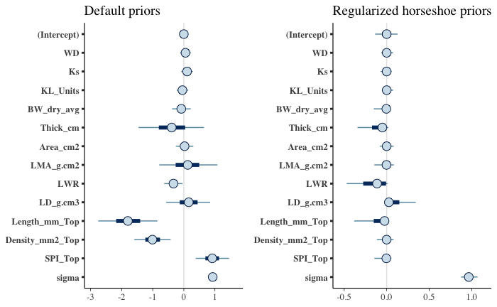

```r
dat <- read.csv("Protea_traits_dataset_for_workshop.csv",
                header = TRUE,
                na.strings = ".")

## drop the first column because it's the intercept and the last because it's sigma
##
for (trait in c("Photo", "WD", "Ks", "KL_Units", "BW_dry_avg", "Thick_cm", "Area_cm2", "LMA_g.cm2", "LWR",
                "LD_g.cm3", "Length_mm_Top", "Density_mm2_Top", "SPI_Top"))
{
  dat[[trait]] <- as.numeric(scale(dat[[trait]]))
}

fit <- stan_glm(Photo ~ WD + Ks + KL_Units + BW_dry_avg + Thick_cm + Area_cm2 + LMA_g.cm2 + LWR + LD_g.cm3 +
                  Length_mm_Top + Density_mm2_Top + SPI_Top,
                data = dat,
                family = gaussian(),
                refresh = 0)
fit_default_df <- as.data.frame(fit)

## n is the number of observations
## D is the number of covariates
## p0 is the expected number of important covariates
##
n <- nrow(dat)
D <- ncol(fit_default_df) - 2
p0 <- 3
tau0 <- p0/(D - p0) * 1/sqrt(n)
prior_coeff <- hs(global_scale = tau0, slab_scale = 1)

fit_hs<- stan_glm(Photo ~ WD + Ks + KL_Units + BW_dry_avg + Thick_cm + Area_cm2 + LMA_g.cm2 + LWR + LD_g.cm3 +
                    Length_mm_Top + Density_mm2_Top + SPI_Top,
                  data = dat,
                  family = gaussian(),
                  refresh = 0,
                  prior = prior_coeff)
fit_hs_df <- as.data.frame(fit_hs)

default <- plot(fit) + ggtitle("Default priors")
horseshoe <- plot(fit_hs) + ggtitle("Regularized horseshoe priors")
ggarrange(default, horseshoe, nrow = 1)
```

This analysis suggests that only four of the covariates have reasonably reliable associations with photosynthesis: leaf thickness, leaf length/width ratio, leaf density, and stomatal length.

That being said, we might want to leave a couple of traits out of this analysis. For example,
$$\eqalign{
\mbox{LMA} &=& \frac{\mbox{leaf mass}}{\mbox{leaf area}} \\
\mbox{leaf density} &=& \frac{\mbox{leaf mass}}{\mbox{leaf volume}} \\
&=& \frac{\mbox{leaf mass}}{\mbox{leaf area}\times\mbox{leaf thickness}} \quad .
}$$
Similarly,
$$\mbox{SPI} = \mbox{stomatal pore length}^2\times\mbox{stomatal density} \quad .$$

Arguably then, we shouldn’t include either LMA or SPI in the analyses in the first place, since they are calculated from other covariates. Let’s rerun the analyses leaving them out and see what happens.

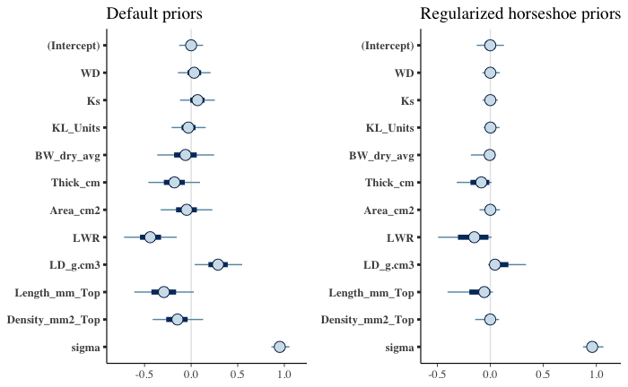

```r
fit <- stan_glm(Photo ~ WD + Ks + KL_Units + BW_dry_avg + Thick_cm + Area_cm2 + LWR + LD_g.cm3 +
                  Length_mm_Top + Density_mm2_Top,
                data = dat,
                family = gaussian(),
                refresh = 0)
fit_default_df <- as.data.frame(fit)

## n is the number of observations
## D is the number of covariates
## p0 is the expected number of important covariates
##
n <- nrow(dat)
D <- ncol(fit_default_df) - 2
p0 <- 3
tau0 <- p0/(D - p0) * 1/sqrt(n)
prior_coeff <- hs(global_scale = tau0, slab_scale = 1)

fit_hs<- stan_glm(Photo ~ WD + Ks + KL_Units + BW_dry_avg + Thick_cm + Area_cm2 + LWR + LD_g.cm3 +
                    Length_mm_Top + Density_mm2_Top,
                  data = dat,
                  family = gaussian(),
                  refresh = 0,
                  prior = prior_coeff)
fit_hs_df <- as.data.frame(fit_hs)

default <- plot(fit) + ggtitle("Default priors")
horseshoe <- plot(fit_hs) + ggtitle("Regularized horseshoe priors")
ggarrange(default, horseshoe, nrow = 1)
```

The predictions from the two models are highly correlated, but for any one point the predictions are less extreme in the model with regularized horseshoe priors.

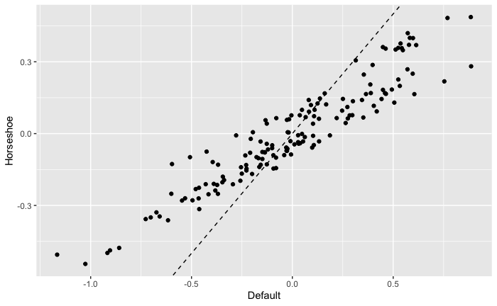

```r
pred_default <- posterior_predict(fit)
pred_hs <- posterior_predict(fit_hs)

for_plot <- data.frame(Default = apply(pred_default, 2, mean),
                       Horseshoe = apply(pred_hs, 2, mean))
p <- ggplot(for_plot, aes(x = Default, y = Horseshoe)) + geom_point() +
  geom_abline(slope = 1, intercept = 0, linetype = "dashed")
p
```

I placed a pretty high premium on parsimony in setting the regularized horseshoe prior. I said that I expected only 3 of the 10 (or 12 before eliminating LMA and SPI) covariates to show a strong relationship. That seems a bit extreme, since I’ve got traits related to stomata, to invetment in leaves, to leaf shape, to wood structure, and to water flow in stems. That’s five different types of traits. Let’s see what happens if I change `p0` to 5.

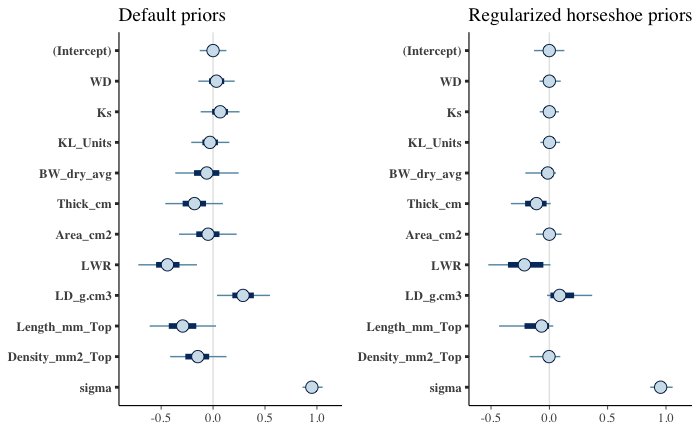

```r
## n is the number of observations
## D is the number of covariates
## p0 is the expected number of important covariates
##
n <- nrow(dat)
D <- ncol(fit_default_df) - 2
p0 <- 5
tau0 <- p0/(D - p0) * 1/sqrt(n)
prior_coeff <- hs(global_scale = tau0, slab_scale = 1)

fit_hs<- stan_glm(Photo ~ WD + Ks + KL_Units + BW_dry_avg + Thick_cm + Area_cm2 + LWR + LD_g.cm3 +
                    Length_mm_Top + Density_mm2_Top,
                  data = dat,
                  family = gaussian(),
                  refresh = 0,
                  prior = prior_coeff)
fit_hs_df <- as.data.frame(fit_hs)

default <- plot(fit) + ggtitle("Default priors")
horseshoe <- plot(fit_hs) + ggtitle("Regularized horseshoe priors")
ggarrange(default, horseshoe, nrow = 1)
```

That didn’t change the results much at all. There may be a bit more of a hint that bark width shows an association than there was before, but it’s still only a hint.

## Model choice

Leave one out cross validation (LOO) is a useful way to compare models, and it’s easy to do once you’ve fit two models that you want to compare.

```r
default_loo <- loo(fit)
```

```
Found 1 observation(s) with a pareto_k > 0.7. We recommend calling 'loo' again with argument 'k_threshold = 0.7' in order to calculate the ELPD without the assumption that these observations are negligible. This will refit the model 1 times to compute the ELPDs for the problematic observations direc…
```

You might get a warning message from `loo()`. If you do, pay attention to it, and run `loo()` again.

```r
default_loo <- loo(fit, k_threshold = 0.7)
```

```
1 problematic observation(s) found.
Model will be refit 1 times.

Fitting model 1 out of 1 (leaving out observation 102)
```

```r
hs_loo <- loo(fit_hs)

default_loo
```

```
Computed from 4000 by 151 log-likelihood matrix
```

|  | Estimate | SE |
| --- | --- | --- |
| elpd_loo | -213.5 | 11.5 |
| p_loo | 12.1 | 2.1 |
| looic | 427.0 | 23.0 |

```
------
Monte Carlo SE of elpd_loo is 0.1.

All Pareto k estimates are good (k < 0.5).
See help('pareto-k-diagnostic') for details.
```

```r
hs_loo
```

```
Computed from 4000 by 151 log-likelihood matrix
```

|  | Estimate | SE |
| --- | --- | --- |
| elpd_loo | -212.2 | 10.7 |
| p_loo | 8.6 | 1.6 |
| looic | 424.3 | 21.4 |

```
------
Monte Carlo SE of elpd_loo is 0.1.

All Pareto k estimates are good (k < 0.5).
See help('pareto-k-diagnostic') for details.
```

```r
loo_compare(default_loo, hs_loo)
```

```
       elpd_diff se_diff
fit_hs  0.0       0.0
fit    -1.3       2.4
```

LOO suggests that the model with regularized horseshoe priors is a bit better in terms of predictive performance than the model with default priors. To be fair, the difference is only about half the standard error, and all you can really say is that the predictive performance of the two models isn’t noticeably different.

```r
summary(fit_hs, digits = 3, prob = c(0.025, 0.1, 0.5, 0.9, 0.975))
```

```
Model Info:
 function:     stan_glm
 family:       gaussian [identity]
 formula:      Photo ~ WD + Ks + KL_Units + BW_dry_avg + Thick_cm + Area_cm2 +
       LWR + LD_g.cm3 + Length_mm_Top + Density_mm2_Top
 algorithm:    sampling
 sample:       4000 (posterior sample size)
 priors:       see help('prior_summary')
 observations: 151
 predictors:   11

Estimates:
                  mean   sd     2.5%   10%    50%    90%    97.5%
(Intercept)     -0.001  0.078 -0.159 -0.100 -0.001  0.097  0.153
WD               0.003  0.054 -0.112 -0.056  0.000  0.065  0.130
Ks              -0.001  0.049 -0.111 -0.053  0.000  0.055  0.111
KL_Units         0.005  0.051 -0.101 -0.049  0.001  0.062  0.119
BW_dry_avg      -0.038  0.081 -0.248 -0.151 -0.013  0.032  0.085
Thick_cm        -0.126  0.113 -0.368 -0.283 -0.111  0.001  0.026
Area_cm2        -0.001  0.067 -0.157 -0.074  0.000  0.067  0.147
LWR             -0.221  0.178 -0.575 -0.463 -0.214  0.000  0.022
LD_g.cm3         0.122  0.130 -0.035 -0.006  0.088  0.315  0.413
Length_mm_Top   -0.121  0.153 -0.498 -0.351 -0.066  0.014  0.065
Density_mm2_Top -0.018  0.079 -0.231 -0.110 -0.003  0.057  0.131
sigma            0.957  0.059  0.851  0.885  0.954  1.034  1.079

Fit Diagnostics:
           mean   sd     2.5%   10%    50%    90%    97.5%
mean_PPD -0.002  0.110 -0.217 -0.143 -0.001  0.141  0.206

The mean_ppd is the sample average posterior predictive distribution of the outcome variable (for details see help('summary.stanreg')).

MCMC diagnostics
                mcse  Rhat  n_eff
(Intercept)     0.001 1.000 5646
WD              0.001 1.000 5054
Ks              0.001 1.000 4369
KL_Units        0.001 1.000 4744
BW_dry_avg      0.002 1.000 2335
Thick_cm        0.003 1.001 1599
Area_cm2        0.001 1.000 3678
LWR             0.004 1.001 1567
LD_g.cm3        0.003 1.001 1642
Length_mm_Top   0.004 1.000 1786
Density_mm2_Top 0.001 1.000 3796
sigma           0.001 1.000 3893
mean_PPD        0.002 1.001 4499
log-posterior   0.167 1.001  989

For each parameter, mcse is Monte Carlo standard error, n_eff is a crude measure of effective sample size, and Rhat is the potential scale reduction factor on split chains (at convergence Rhat=1).
```

## Comparing predictions

We can also directly compare predictions with observations in both models. In the figures that follow `y` is the observed value, and `Average y_rep` is the mean of the posterior predictions for that observation. Remember that we got `pred_default` and `pred_hs` above using `posterior_predict()`.

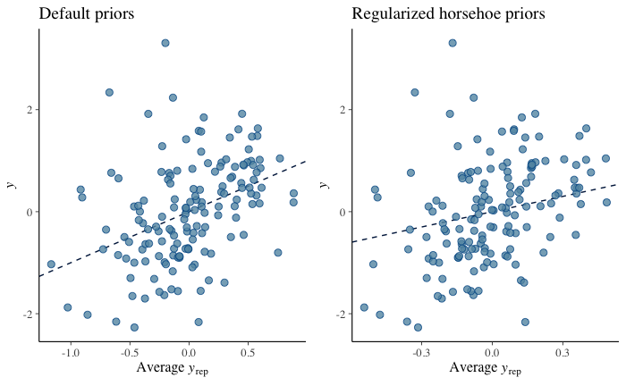

```r
default <- ppc_scatter_avg(dat$Photo, pred_default) + ggtitle("Default priors")
horseshoe <- ppc_scatter_avg(dat$Photo, pred_hs) + ggtitle("Regularized horsehoe priors")
ggarrange(default, horseshoe, nrow = 1)
```

You can see that the slope of the relationship between `y` and `y_rep` is steeper in the model with default priors. That’s because *all* of the covariates are contributing to the prediction in the model with default priors, while only 5 of them are contributing to the prediction with horseshoe priors. The model comparison using `loo()` suggested that in terms of predicting new observations there’s little difference between the models. As suggested by the different slopes, the model with default priors does, however, fit the observed data better than the model with regularized horseshoe priors, as we can see by comparing $R^2$.

```r
R2_default <-bayes_R2(fit)
R2_horseshoe <- bayes_R2(fit_hs)
round(median(R2_default), 3)
```

```
[1] 0.192
```

```r
round(median(R2_horseshoe), 3)
```

```
[1] 0.089
```

Having said that, if we plot the whole posterior distribution, the overall fit really isn’t as different as you might thing from just looking at the median.

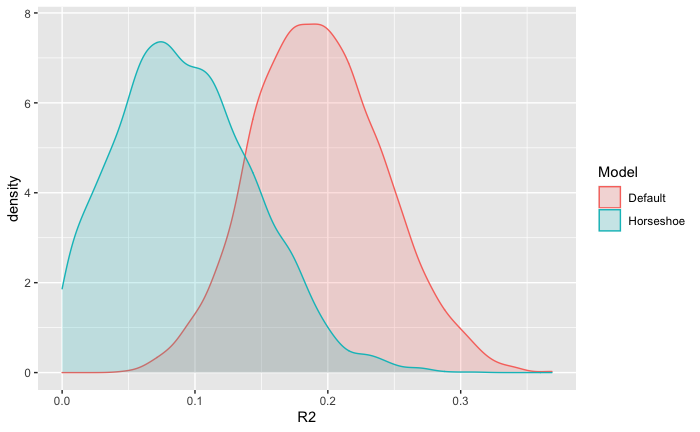

```r
for_plot <- data.frame(Model = c(rep("Default", length(R2_default)),
                                 rep("Horseshoe", length(R2_horseshoe))),
                       R2 = c(R2_default, R2_horseshoe))
ggplot(for_plot, aes(x = R2, color = Model, fill = Model)) + geom_density(alpha = 0.2)
```

[^1]: See Holsinger and Wallace *Molecular Ecology* 13:887; 2004 doi: 10.1111/j.1365-294X.2004.02052.x
[^2]: We’ll ignore for the time being that there are different species measured at different sites in these data.
[^3]: See this [R notebook](http://darwin.eeb.uconn.edu/pages/variable-selection/horseshoe-priors.nb.html) for more information about regularized horseshoe priors. It includes a reference to the Pironen and Vehtari paper if you really want to dig into this. Be aware, however, that there’s some pretty scary math in that paper. It’s not easy to read.
[^4]: You can also use regularized horseshoe priors in `brms`. The syntax is slightly different, but you can chant the same incantation as I use here to set `global_scale`. It also has a couple of other options that you’ll want to investigate if you use `brms`.